# Knees

Do Won Kim

2023-08-16

```r
# Load packages
library(readr)
library(tidyverse)
library(ggplot2)
library(ggthemes)
library(grid)
library(gridExtra)
library(DT)
library(lubridate)
library(scales)
library(dplyr)
library(magrittr)
```

**Q1.** Across the whole sample, how many tweets do we need to pull to reach a specific % of friends? (rough way to estimating expenditure)

※ Be cautious as this kneedle algorithm might not work well with our data with lots of noise

1. Aggregate plot with x-axis = # of tweets, y-axis = avg # of friends seen (%)
- Polynomial interpolation method for fitting a spline to the input x and y data points
- Sensitivity = 1.0 (changing sensitivity does not make any differences)

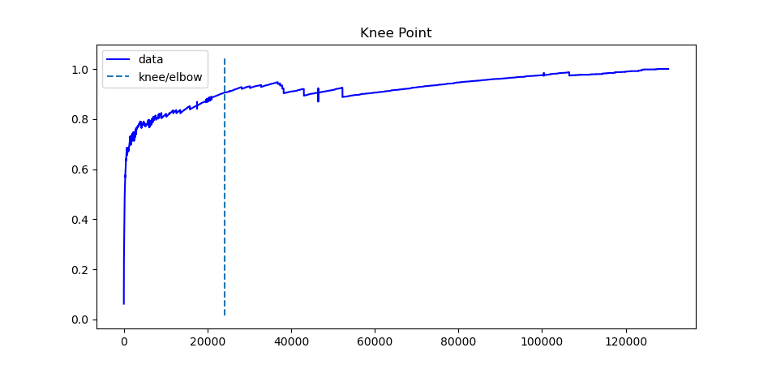

**Knee point: 24,029(=x), 0.905(=y)**

In aggregate, to get about 90% of distinct friends accounts seen, we need to pull 24K tweets.

---

- Without polynomial interpolation (default setting)
- Sensitivity makes differences so I chose the one that results in the highest y value

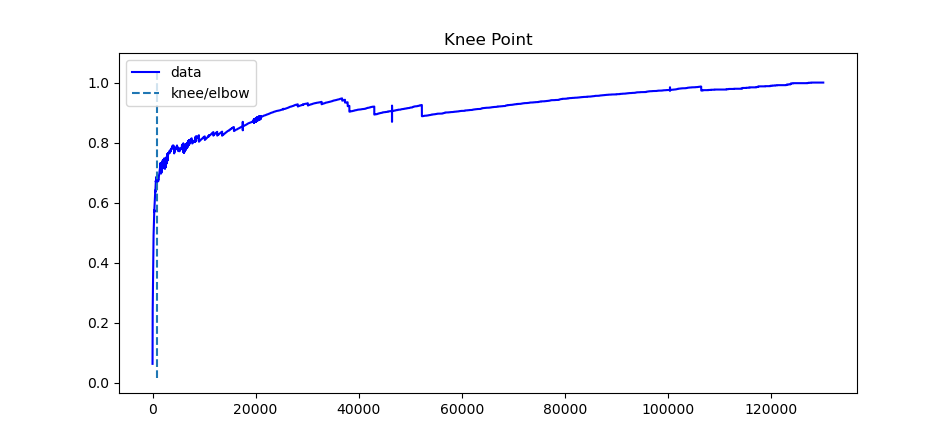

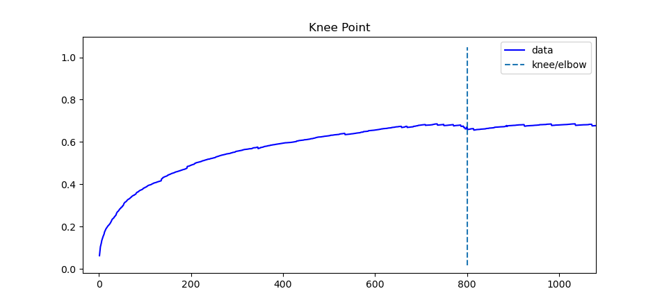

**Knee point: 800 (=x), 0.673(=y) (S=1000)**

In aggregate, to get about 67.3% of distinct friends seen, we need to pull 800 tweets.

**Q2.** For each user, how many tweets do we need to pull to reach a specific % of friends (based on the rate)? (personalized/customized)

**What I did:** Since changing the sensitivity might change the result / each user might have different sensitivities, I varied sensitivity and calculated the knees (and corresponding values of old_x & new_y) for each user.

- Sensitivity levels: [1, 100, 1000, 2000]
- Interpolation method: polynomial with default degree (=7)

For example, the data frame looks like this:

```r
# Load data
df_kns <- read_csv("df_kns.csv")
df_kns = df_kns[,-1]
df_kns = df_kns |>
  relocate(user_code, sensitivity)

datatable(df_kns,
          filter="top")
```

|  | user_code | sensitivity | knee | knee_y |
| --- | --- | --- | --- | --- |
| 1 | 0 | 1 | 171 | 0.9 |
| 2 | 0 | 100 | 171 | 0.9 |
| 3 | 0 | 1000 | 171 | 0.9 |
| 4 | 0 | 2000 | 171 | 0.9 |
| 5 | 1 | 1 | 74 | 0.359375 |
| 6 | 1 | 100 | 1189 | 0.9375 |
| 7 | 1 | 1000 |  |  |
| 8 | 1 | 2000 |  |  |
| 9 | 2 | 1 | 187 | 0.456140350877193 |
| 10 | 2 | 100 |  |  |

[output cut: 230 more lines]

- Note that blank means N/A; and also that the algorithm/kneed package has an online version where we could detect knees as data comes in online (in case we are going with the unfollow + reverse chronological option rather than muting).
- So, we have the knee points for each user and each sensitivity level.

Then, what the knees look like across users? (Avg & SD)

```r
# Make a table of the individual knees,
# which includes sensitivity, mean/sd(knee), mean/sd(knee_y) across users

df_kns %>%
  dplyr::select(-user_code) %>%
  group_by(sensitivity) %>%
  summarize(
    avg_x = round(mean(knee, na.rm = T), 3),
    sd_x = round(sd(knee, na.rm = T), 3),

    avg_y = round(mean(knee_y, na.rm = T), 3),
    sd_y = round(sd(knee_y, na.rm = T),3)
  ) -> ttibe

datatable(ttibe)
```

|  | sensitivity | avg_x | sd_x | avg_y | sd_y |
| --- | --- | --- | --- | --- | --- |
| 1 | 1 | 102.4 | 137.988 | 0.322 | 0.309 |
| 2 | 100 | 5465.093 | 10931.655 | 0.811 | 0.21 |
| 3 | 1000 | 10457.071 | 22422.245 | 0.848 | 0.287 |
| 4 | 2000 | 10457.071 | 22422.245 | 0.848 | 0.287 |

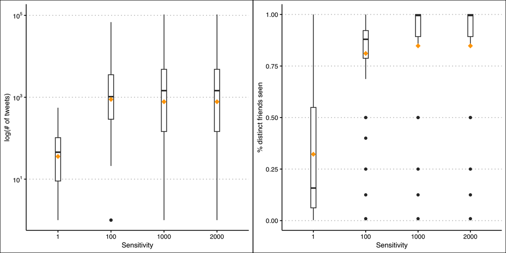

```r
df_kns %>%
  dplyr::select(-user_code) %>%
  mutate(sensitivity = as.factor(sensitivity)) %>%
  ggplot(aes(x=sensitivity, y=knee)) +
  #geom_violin(trim=F) +
  # coord_flip() +
  theme_clean() +
  xlab("Sensitivity") +
  ylab("log(# of tweets)") +
  geom_boxplot(width=0.1) +
  #scale_x_discrete(limits=c("1","100","1000")) +
  stat_summary(fun.y=mean, geom="point", shape=18, size=3, color="orange") +
  scale_y_log10(labels = scales::label_log()) -> p1_knee

df_kns %>%
  dplyr::select(-user_code) %>%
  mutate(sensitivity = as.factor(sensitivity)) %>%
  ggplot(aes(x=sensitivity, y=knee_y)) +
  #geom_violin(trim=F) +
  #coord_flip() +
  theme_clean() +
  xlab("Sensitivity") +
  ylab("% distinct friends seen") +
  geom_boxplot(width=0.1) +
 # scale_x_discrete(limits=c("1","100","1000")) +
  stat_summary(fun.y=mean, geom="point", shape=18, size=3, color="orange") -> p1_kneey

grid.arrange(p1_knee, p1_kneey, ncol=2)
```

- sensitivity = 100 | on average, to get 81.1% of distinct friends seen, we need to have 5465 tweets.

Two options?

1. Stop when we pull 24K/800 tweets (each corresponding to 90%/67.3% of distinct friends seen in aggregate)
   - Remember that this estimation is based on 60 users - so we have to re-estimate for the 10K users who we think will authorize the access in the screening process
     - 24K tweets in 60-user sample -> 400 tweets per user -> for 10K users, 4M tweets needed
     - **800 tweets in 60-user sample -> 13.3 tweets per user -> for 10K users, 133,333 tweets needed**
2. Stop when we pull 5465 tweets to get 81.1% of distinct friends seen on average
   - Remember that this estimation is based on 60 users - so we have to re-estimate for the 10K users who we think will authorize the access in the screening process
     - **5465 tweets in 60-user sample -> 91 tweets per user -> for 10K users, 910,000 tweets needed**
- From Twitter website:
  - Basic: $100 per month access up to 50K Tweets/month, and 2 App environments (should check whether this information is out-dated; it’s from twitter website)
  - **Pro**: $5K per month access up to 1M (1,000,000) Tweets/month and 3 app IDs
- In the screening stage (after the authorization), we start to pull tweets from ~ 10K participants who followed our study account and stop pulling when we reach (1) around 150,000 tweets or (2) 910,000 tweets in aggregate.
- ~4000 participants will be invited in wave 2, based on how many low quality accounts are appearing in the reverse chronological timelines.
- (in the case of choosing (1)) If needed, use the rest of the capacity within a month to collect more from those ~4000 participants (about 850,000 tweets)
- Though, we might under-collect tweets for some users while over-collect for some others (since the rates/speeds at which each user’s home timeline is getting tweets are different)